Regresión Lineal Múltiple - Semana 05

Freddy Hernández

fhernanb@unal.edu.co

Profesor Asociado - Departamento de Estadística

Universidad Nacional de Colombia, Sede Medellín

1 / 37

Regresión lineal múltiple

En análisis de regresión usualmente se utiliza más de una variable predictora para

modelar el valor de una variable respuesta de interés Y. Si la relación funcional entre la

respuesta Yy las variables predictoras es lineal en los parámetros, se llega al caso de la

regresión lineal múltiple (RLM).

En el ajuste y análisis de este modelo se obtienen resultados que son extensiones de los

que se obtuvieron en regresión lineal simple.

A continuación se introducen nociones preliminares relacionados con vectores de

variables aleatorias, que permite un manejo matemático simpliﬁcado del modelo de RLM.

2 / 37

Nociones reliminares relacionados con vectores de variables

aleatorias

Para facilitar la notación y el desarrollo de algunas pruebas se utiliza con frecuencia una

escritura del modelo en forma matricial, la cual requiere establecer algunas deﬁniciones

que se presentan a continuación.

3 / 37

Vectores aleatorios

Sean y1,y2,...,ynvariables aleatorias con medias µ1, µ2, . . . , µny varianzas

σ2

1, σ2

2, . . . , σ2

n, respectivamente.

Sean σij =Cov [yi,yj] = E[(yi−µi) (yj−µj)] la covarianza entre las variables yieyj,

con i,j=1,2,...,n.

Se deﬁne el vector y= [y1,y2,...,yn]′, el cual se dice es un vector aleatorio con

media o vector de medias yvarianza o matriz de varianzas-covarianzas dadas por:

µy=

E[y1]

.

.

.

E[yn]

=

µ1

.

.

.

µn

yΣy=

σ11 σ12 · · · σ1n

σ21 σ22 · · · σ2n

.

.

..

.

.....

.

.

σn1σn2· · · σnn

4 / 37

Observe que en la matriz Σylos elementos:

▶σij =σji , es decir, la matriz Σyes una matriz simétrica.

▶σii =σ2

i, es decir, los elementos de la diagonal principal de Σycorresponden a las

varianzas de las variables yi.

Por lo tanto se puede escribir,

Σy=

σ2

1σ12 · · · σ1n

σ12 σ2

2· · · σ2n

.

.

..

.

.....

.

.

σ1nσ2n· · · σ2

n

5 / 37

En resumen, la matriz de varianzas-covarianzas asociada a un vector aleatorio es una

matriz:

▶Cuadrada y simétrica, de orden igual al tamaño del vector aleatorio.

▶La diagonal principal contiene las varianzas asociadas a cada elemento del vector

aleatorio.

▶Por fuera de la diagonal están las covarianzas entre los pares de elementos del

vector aleatorio.

6 / 37

Algunas propiedades del valor esperado y la varianza de un vector

aleatorio

Sea

y

un vector aleatorio n

×

1 con media (vector de medias)

µy

y varianza (matriz de

varianzas-covarianzas) Σy, como fueron deﬁnidos antes.

Sean Auna matriz m×nde constantes y bun vector m×1 de constantes, entonces:

1. EhAyi=AEhyi=Aµy.

2. EhAy +bi=EhAyi+E[b] = Aµy+b.

3. Var hAyi=AVar hyiA′=AΣyA′.

4. Var hAy +bi=Var hAyi+Var [b] = AΣyA′+0=AΣyA′.

7 / 37

Observe que se conservan las propiedades de la esperanza y la varianza del caso

univariado, por ejemplo.

▶E[b] = b, es decir, la esperanza de un vector constante es el mismo vector

constante.

▶Var [b] = O, donde Oes una matriz nula (cuyos elementos son todos cero) de

orden m

×

m. Así, la varianza de un vector constante es una matriz cuadrada nula

de orden correspondiente al número de elementos del vector constante.

▶Var hAyi=AΣyA′, es decir, la varianza de un vector aleatorio por una matriz

constante resulta en una forma cuadrática de la matriz constante que involucra a la

varianza del vector aleatorio.

8 / 37

Algunas deﬁniciones básicas en teoría matricial

Sean Aybmatrices de constantes de orden n×nym×nrespectivamente.

Sean

x

=

[x1,...,xn]′

un vector de variables de orden n

×

1;

a

un vector de constantes

de orden n×1; y Ila matriz identidad de orden n.

Entonces:

1. (BA)′=A′B′, la traspuesta de un producto es igual al producto invertido de las

traspuestas.

2. Aes simétrica si A′=A.

3. Aes idempotente si AA =A2=A.

9 / 37

4. Si Aes simétrica e idempotente, entonces (I−A)también es simétrica e

idempotente.

5. Forma cuadrática: la función x′Ax =Pn

i=1Pn

j=1aij xixjse le llama forma

cuadrática de x, donde aij es la ij-ésima componente de la matriz A.

6. Matriz deﬁnida positiva y semideﬁnida positiva: la matriz Ase dice que es:

a) Deﬁnida positiva, si x′Ax >0,∀x.

b) Semideﬁnida positiva si x′Ax ≥0,∀x.

10 / 37

Algunas propiedades de derivadas vectoriales o matriciales

Sean Auna matriz de constantes de orden n×n;x= [x1,...,xn]′un vector de

variables de orden n×1; y aun vector de constantes de orden n×1.

Entonces:

1. ∂(a′x)

∂x=∂(x′a)

∂x=a.

2. ∂(x′x)

∂x=2x.

3. ∂(x′Ax)

∂x=Ax +A′x, pero si Aes simétrica, entonces ∂(x′Ax)

∂x=2Ax.

11 / 37

Algunos resultados distribucionales para vectores aleatorios

Sea yun vector aleatorio normal n-variado con media µyy matriz de

varianzas-covarianzas no singular Σy, es decir, y∼Nnµy,Σy.

Sean Auna matriz n×nde constantes y Uuna forma cuadrática de ydeﬁnida como:

U=y′Ay.

Se tienen los siguientes resultados:

1. Si AΣyóΣyAes una matriz idempotente de rango p, entonces

U∼χ2

p,λ

donde, λ=µ′

yAµyes el parámetro de no centralidad de la distribución

chi-cuadrado.

12 / 37

2. Si Σy=σ2IyAes idempotente y de rango p, entonces

U

σ2∼χ2

p,λ

donde, λ=µ′

yAµy/σ2.

3. Sean Buna matriz m×nyWuna forma lineal deﬁnida como: W=By,

entonces la forma cuadrática U=y′Ay yWson independientes si

BΣyA=O

donde Oes la matriz nula de orden m×n.

Nota: Si Σy=σ2I, entonces UyWson independientes si BA =O.

13 / 37

4.

Sean

B

una matriz n

×

ny

V

=

y′By

otra forma cuadrática de

y

, entonces las dos

formas cuadráticas UyVson independientes si

AΣyB=O

Nota: Si Σy=σ2I, entonces UyVson independientes si AB =O.

14 / 37

Deﬁnición del modelo de regresión lineal múltiple (RLM)

Considere el caso en el cual se desea modelar la variabilidad total de una variable

respuesta de interés, en función de relaciones lineales con dos o más variables

predictoras, formuladas simultáneamente en un único modelo.

Suponemos en principio que las variables predictoras guardan poca asociación lineal

entre sí, es decir, cada variable predictora aporta información independiente de las

demás predictoras presentes en el modelo (hasta cierto grado, la información aportada

por cada una no es redundante).

La ecuación del modelo de regresión en este caso es:

Yi=β0+β1Xi1+β2Xi2+· · · +βkXik +εi,i=1,2,...,n.

15 / 37

Este modelo es de primer orden ya que no se presentan efectos de interacción entre las k

variables predictoras, donde:

▶β0, β1, . . . , βk: son los pparámetros del modelo (uno por cada variable predictora

más uno por el intercepto, esto es p=k+1).

▶Xi1,Xi2,...,Xik , son los valores en la i-ésima observación muestral, de las k

variables predictoras consideradas en el modelo.

▶εi

iid

∼N0, σ2,i=1,2,...,n.

16 / 37

Estadísticamente, se establece que la respuesta media está dada por:

E(Y|X1,X2,...,Xk) = β0+β1X1+β2X2+· · · +βkXk,

la cual representa un hiperplano en un espacio de dimensión

k+1

, llamado superﬁcie de

regresión o superﬁcie de respuesta.

Similar al modelo de regresión lineal simple, bajo los supuestos de normalidad,

independencia y varianza constante de los errores, se tiene que:

Yi|Xi1,...,Xik

ind

∼Nβ0+β1Xi1+· · · +βkXik , σ2,i=1,2,...,n.

17 / 37

Signiﬁcado de los coeﬁcientes

El parámetro β0, el intercepto Ydel plano, representará la respuesta media de Y

cuando en el conjunto de observaciones se incluye la coordenada

(X1,X2,...,Xk)=(0,0,...,0),

de lo contrario si tal coordenada no es observada o no está incluida en el rango

experimental, entonces β0no será interpretable.

Los parámetros βj,j=1,2,...,k, indican el cambio en la respuesta media de Ypor

unidad de incremento en la respectiva variable Xj, cuando las demás predictoras

permanecen constantes (sin importar en qué nivel son ﬁjadas estas últimas).

18 / 37

Como los efectos de una predictora sobre la respuesta media no dependen del nivel de

las demás, tales efectos son denominados efectos aditivos. Los parámetros βj, son

también llamados coeﬁcientes de regresión parcial porque reﬂejan el efecto parcial de

una variable predictora sobre la respuesta media en presencia de las demás predictoras

que aparecen en el modelo.

NOTA: El término modelo lineal signiﬁca que el modelo es lineal en los parámetros, lo

cual no hace referencia a la forma de la superﬁcie de respuesta.

19 / 37

Tipos de variables y de efectos en los modelos

Las variables predictoras pueden ser:

▶Cuantitativas, caso en el cual se supone se miden sin error (o el error es

despreciable).

▶Cualitativas o categóricas, en este caso su manejo en el modelo se realiza a través

de la deﬁnición de variables indicadoras, las cuales toman valores de 0 ó 1.

En general, una variable cualitativa con cclases se representa mediante

c−1

variables

indicadoras, puesto que cuando en una observación dada, todas las c−1 primeras

indicadoras son iguales a cero, entonces la variable cualitativa se haya en su última clase.

20 / 37

Por ejemplo, suponga que en un modelo de regresión para el gasto mensual por familia

en actividades recreativas, se tiene entre las variables predictoras el estrato

socioeconómico, deﬁnido en cinco niveles, luego, basta deﬁnir las primeras cuatro

indicadoras de la siguiente forma:

I1=(1 familia en estrato 1

0 otro caso I2=(1 familia en estrato 2

0 otro caso

I3=(1 familia en estrato 3

0 otro caso I4=(1 familia en estrato 4

0 otro caso

21 / 37

En el caso con variables predictoras cuantitativas, existe la llamada regresión polinomial

en la que se utilizan términos cuadráticos y de orden superior de estas variables, como

en los diseños experimentales para optimización de procesos mediante la metodología de

superﬁcie de respuesta.

A pesar de la naturaleza no lineal de tales superﬁcies de respuesta, estos modelos hacen

parte del modelo de regresión lineal múltiple.

Algunos modelos pueden usar funciones de respuesta curvilíneas, en los cuales se utilizan

variables transformadas de forma compleja, para linealización del modelo.

22 / 37

Otros modelos pueden incluir efectos de interacción, es decir cuando los efectos de una

variable predictora depende de los niveles de otras variables predictoras incluidas en el

modelo.

Por ejemplo, suponga un modelo de regresión con las variables predictoras

X1

y

X2

, que

incluye tanto los efectos principales como el efecto de interacción de estas dos variables.

Este modelo corresponde a:

Yi=β0+β1Xi1+β2Xi2+β3X1X2+εi.

El término de interacción es representado por

β3X1X2

. Para expresar el anterior modelo

en términos del modelo lineal múltiple, deﬁnimos simplemente

X3=X1X2

y rescribimos

el modelo como:

Yi=β0+β1Xi1+β2Xi2+β3X3+εi.

23 / 37

En este último tipo de modelo los coeﬁcientes de regresión de los términos individuales

Xjya no tienen el signiﬁcado dado antes, debido a la presencia de la interacción, es

decir, ya no representan el cambio en la respuesta media cuando se incrementa en una

unidad la respectiva variable predictora, manteniendo constante a las demás.

Para el ejemplo, puede mostrarse mediante derivación, que cuando

X1

se incrementa en

una unidad mientras X2se deja ﬁja, el cambio en la respuesta promedio es β1+β3X2.

Así, los efectos de una variable predictora sobre la respuesta promedio, dado el nivel ﬁjo

de la otra, dependen del nivel en que se halle esta última.

Tenga presente que cualquier modelo que pueda rescribirse en términos del modelo lineal

múltiple, puede trabajarse mediante las técnicas de estimación de mínimos cuadrados, de

lo contrario, el modelo se considera no lineal y sólo pueden obtenerse estimaciones

mediante métodos numéricos complejos.

24 / 37

Chequeo de posibles asociaciones

Inicialmente, puede ser útil realizar chequeos gráﬁcos de la naturaleza y la fuerza de las

asociaciones entre las variables predictoras con la variable respuesta, y aún entre

predictoras.

Una matriz de gráﬁcas de dispersión es la herramienta más útil para visualizar rápida y

simultáneamente estas relaciones. Si las variables predictoras se asocian linealmente a la

variable respuesta, los gráﬁcos de dispersión respectivos deben presentar las nubes de

puntos tendiendo a una línea recta. También se puede chequear si existen relaciones de

tipo no lineal entre las distintas variables, y la presencia de observaciones atípicas.

25 / 37

Por otra parte, se espera que entre las predictoras no existan relaciones lineales fuertes,

pues de lo contrario, habría información que podría ser redundante en el modelo, y se

tendría un problema de multicolinealidad, lo cuál se estudiará en mayor detalle más

adelante en la asignatura.

A veces es útil también acompañar este análisis gráﬁco con la matriz de correlaciones de

las variables del modelo, la cual muestra los coeﬁcientes de correlación entre la variable

respuesta con cada una de las predictoras y también todas las correlaciones entre las

predictoras.

26 / 37

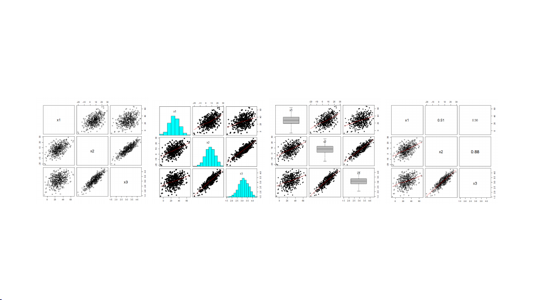

En la siguiente ﬁgura se presentan algunas matrices de gráﬁcos de dispersión para un

conjunto de datos sobre tres variables.

27 / 37

Estimación por mínimos cuadrados de los parámetros

Note que cuando se tienen nobservaciones para el modelo lineal

Yi=β0+β1Xi1+β2Xi2+· · · +βkXik +εi,i=1,...,n,

en realidad se tiene un sistema de necuaciones con p=k+1 incógnitas

correspondiendo al intercepto y los kcoeﬁcientes de regresión, donde los Yiy las Xij

toman valores conocidos en cada caso.

i=1:y1=β0+β1X11 +β2X12 +· · · +βkX1k+ε1

i=2:y2=β0+β1X21 +β2X22 +· · · +βkX2k+ε2

.

.

..

.

.

i=n:yn=β0+β1Xn1+β2Xn2+· · · +βkXnk +εn

28 / 37

Tal sistema expresado en forma matricial corresponde a:

y=Xβ+ε

donde:

y=

Y1

Y2

.

.

.

Yn

es el vector n×1 de observaciones.

β=

β0

β1

.

.

.

βk

es el vector de p×1 parámetros.

29 / 37

X

=

1X11 X12 · · · X1k

1X21 X22 · · · X2k

.

.

..

.

..

.

.· · · .

.

.

1Xn1Xn2· · · Xnk

es una matriz n

×

pcon los valores de predictoras.

ε=

ε1

ε2

.

.

.

εn

es el vector de errores aleatorios.

Los supuestos del modelo sobre los errores establecen que:

εi

iid

∼N0, σ2,i=1,2,...,n

30 / 37

Lo cual en forma matricial establece que el vector ε(de los errores aleatorios) es un

vector aleatorio normal n-variado con valor esperado E(ε) = 0y matriz de varianzas

covarianzas Var (ε) = σ2In, donde Ines la matriz identidad de orden n.

Observe que E(ε) =

0

0

.

.

.

0

yVar (ε) =

σ20· · · 0

0σ2· · · 0

.

.

..

.

.....

.

.

0 0 · · · σ2

.

Por tanto el vector aleatorio

y

tiene valor esperado

Xβ

y la misma matriz de varianzas

covarianzas de ε.

31 / 37

Para la estimación por mínimos cuadrados se buscan los valores estimados de los

parámetros tales que se minimice la suma de cuadrado del error:

Sβ=

n

X

i=1

ε2

i=

n

X

i=1

(Yi−β0−β1Xi1−β2Xi2− · · · − βkXik )2.

Matricialmente,

Sβ=ε′ε=y−Xβ′y−Xβ

=y′y−y′Xβ−β′x′y+β′x′Xβ

=y′y−2β′x′y+β′x′Xβ,

y el estimador de mínimos cuadrados se obtiene al resolver

32 / 37

De donde las ecuaciones normales de mínimos cuadrados para el modelo de RLM son:

x′Xb

β=x′y,

y el vector de los estimadores es b

β= (x′x)−1x′y, cuyos elementos corresponden a los

estimadores de mínimos cuadrados para los parámetros del modelo de RLM. Esto es,

b

β=hb

β0b

β1· · · b

βki′

Luego, la ecuación de regresión ajustada igual a

b

Yi=b

β0+b

β1X1+b

β2X2+· · · +b

βkXk=xib

β.

donde, xies la i-ésima ﬁla de la matrix x.

33 / 37

Algunas propiedades de los estimadores de los parámetros

▶Los estimadores de mínimos cuadrados corresponden a los estimadores de máxima

verosimilitud, bajo el modelo lineal normal.

▶b

βes un estimador insesgado del vector de parámetros β, es decir

Ehb

βi=Ehx′x−1x′yi=β

En efecto, sea

A

=

(x′x)−1x′

una matriz p

×

nde valores ﬁjos (constantes). Entonces,

Ehb

βi=EhAyi=AEhyi=A Xβ=x′x−1x′Xβ=β

34 / 37

La matriz de varianzas covarianzas de b

βes

Var b

β=σ2X′X−1

En efecto,

Var hb

βi=Var hAyi=AVar hyiA′=Aσ2InA′

=σ2x′x−1x′Inhx′x−1x′i′

=σ2x′x−1x′xhx′x−1i′=σ2x′x−1,

La cual tiene en su diagonal principal a las varianzas de los estimadores de los

parámetros, Var b

βj,j=0,1,...,k, y por fuera de su diagonal principal a las

covarianzas entre tales estimadores.

35 / 37

Note que b

β=Ay implica que cada parámetro estimado es una combinación lineal de

las observaciones, así que

b

βj

es una variable aleatoria con distribución normal (ya que los

yi’s son normales).

En resumen, se tiene que:

b

β∼Nβ, σ2x′x−1,

y en el caso particular del estimador del j-ésimo parámetro del modelo se tiene que:

b

βj∼Nβj, σ2cjj ,j=0,1,...,k.

Observe que en las expresiones anteriores σ2es desconocido, de manera que debe

estimarse.

36 / 37

Un estimador de σ2surge del método de máxima verosimilitud al igual que en RLS, el

cual se deﬁne como:

ˆσ2=MSE =Pn

i=1(yi−b

yi)2

n−p=SSE

n−p.

Luego, una estimación de la matriz de varianzas-covarianzas es:

d

Var b

β= ˆσ2x′x−1=MSE x′x−1,

cuyos elementos en la diagonal principal corresponden a las estimaciones de las varianzas

de los respectivos estimadores b

βj, esto es,

d

Var b

βj=MSE cjj ,

donde cjj , es el j-ésimo elemento de la diagonal de la matriz (x′x)−1.

37 / 37